# **Sentimiento y Reacciones en Twitter**

#### **José Manuel Magallanes Ph.D.**

[CRÉDITOS y CONDICIONES DE USO](https://rawgit.com/projectsUW/peru2016elections/master/Credits.html)

Se ha vuelto de interés detectar el [*sentimiento*](https://en.wikipedia.org/wiki/Sentiment_analysis) de los mensajes en Twitter. Para nuestro caso, hemos usado el el clasificador propuesto por [*Elliot Hoffman*](https://github.com/aylliote/senti-py) para el caso especial de la lengua Española. De igual manera, resulta interesante saber si lo que *postean* los candidatos es bienvenido por los usuarios de Twitter.

Como la data se está recolectando para el proceso 2018, presentaremos los Tweets del 15 de julio (fin del mundial de Futbol de Rusia) al día de las elecciones.

Los Tweets han sido *filtrados*, es decir, no aparecen los reTweets que un candidato haya hecho de otro usuario. Así mismo, cada Tweet ha sido depurado, eliminando direcciones web, y palabras con **#**. Cada sentimiento calculado para un Tweet, es acompañado de su aceptación (cantidad de *me gusta*), y de promoción o exposición (cantidad de *retweeteo*).

- Mensajes de Reggiardo
- Mensajes de Belmont
- Mensajes de Urresti
- Mensajes de Lay
- Mensajes de Capuñay
- Mensajes de Beingolea
- Mensajes de Castañeda
- Mensajes de Muñoz
- Mensajes de Salinas
- Mensajes de Gago
- Mensajes de Cornejo
- Mensajes de Fernandez
- Mensajes de Columbus
- Mensajes de Guerra García
- Mensajes de Zurek
- Mensajes de Ocrospoma
- Mensajes de Villacorta
- Mensajes de Velarde
- Mensajes de Gomez Baca

## Los mensajes de Renzo Reggiardo

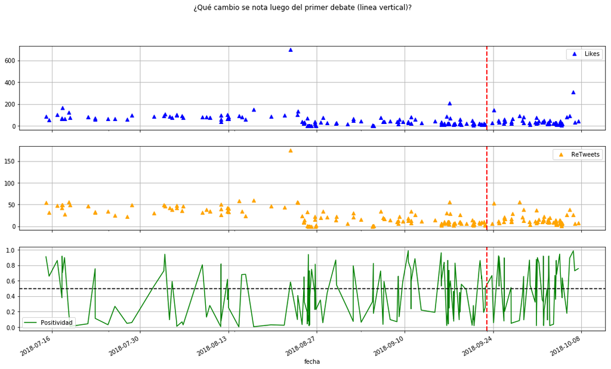

```
Cantidad de Tweets:  201
```

INICIO

## Los mensajes de Ricardo Belmont

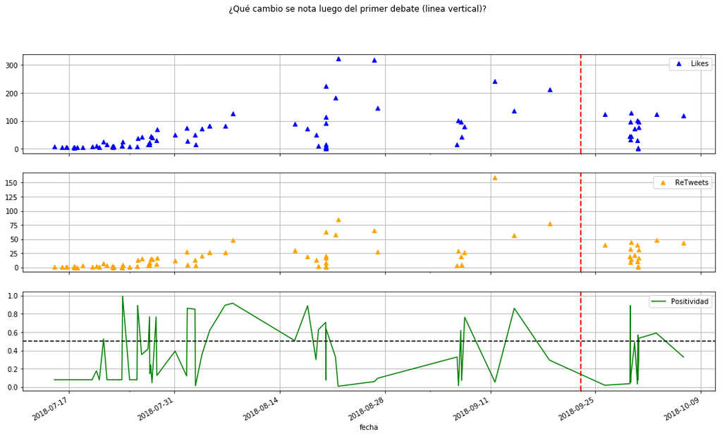

```
Cantidad de Tweets:  81
```

INICIO

## Los mensajes de Daniel Urresti

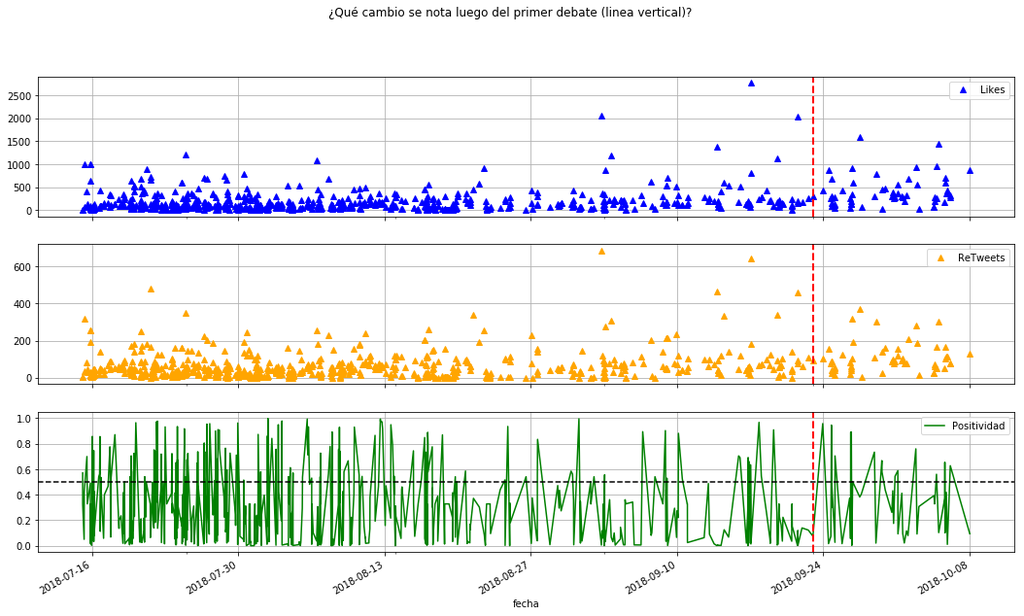

```
Cantidad de Tweets:  1021
```

INICIO

## Los mensajes de Humberto Lay

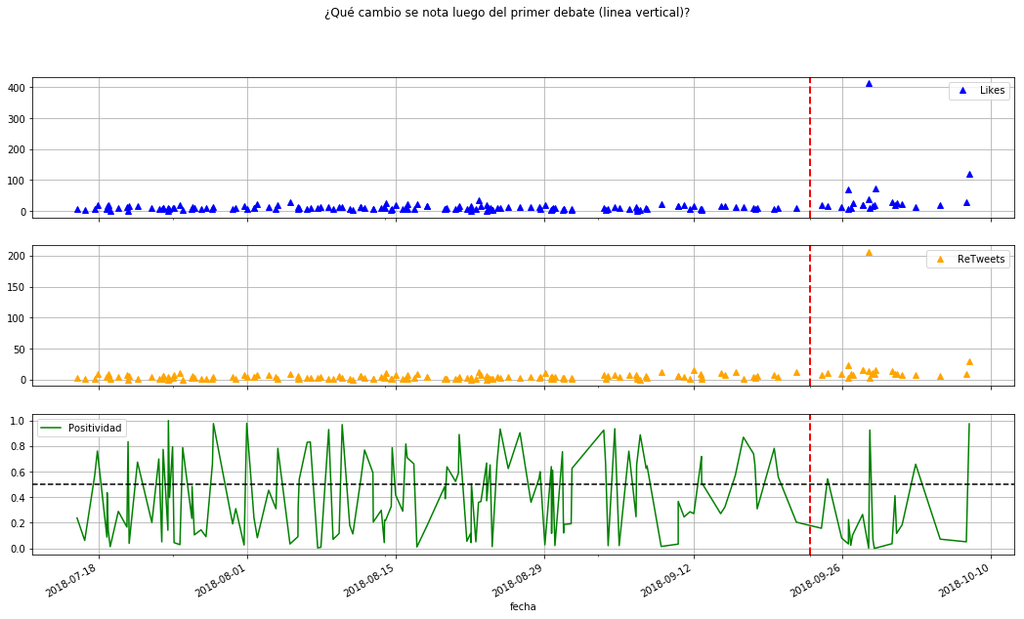

```
Cantidad de Tweets:  167
```

INICIO

## Los mensajes de Esther Capuñay

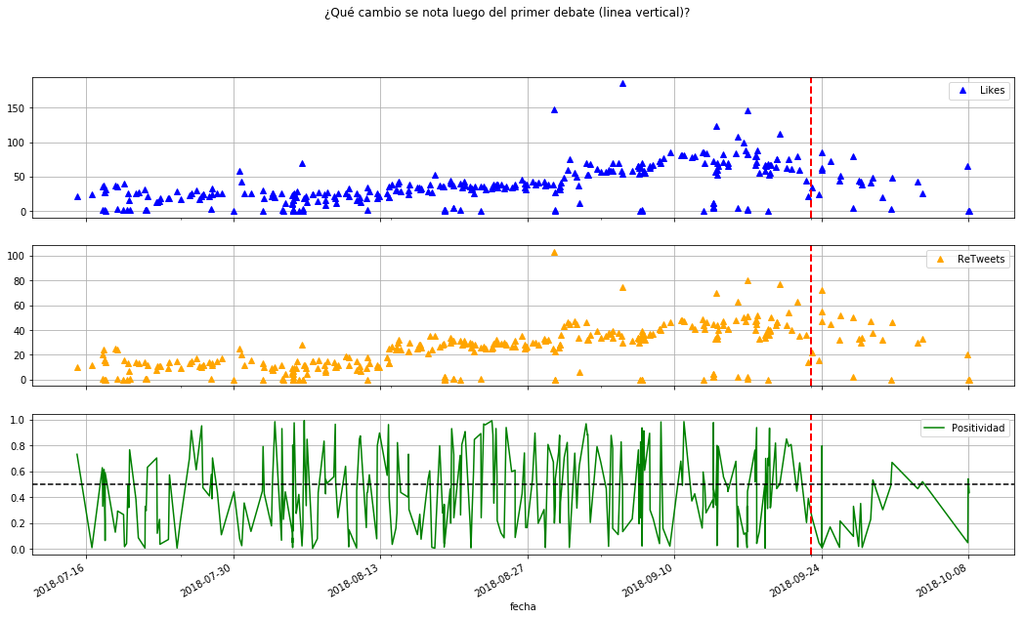

```
Cantidad de Tweets:  326
```

INICIO

## Los mensajes de Alberto Beingolea

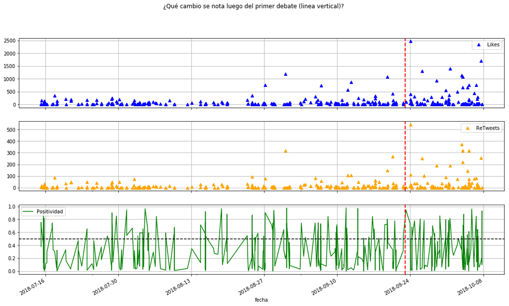

```
Cantidad de Tweets:  579
```

INICIO

## Los mensajes de Luis Castañeda P.

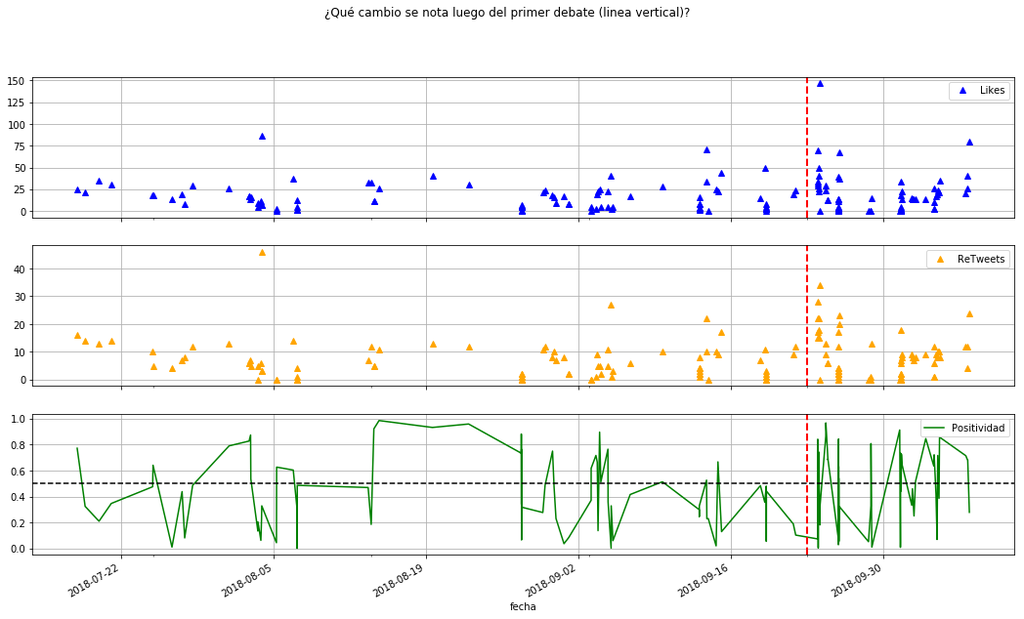

```
Cantidad de Tweets:  155
```

INICIO

## Los mensajes de Jorge Muñoz

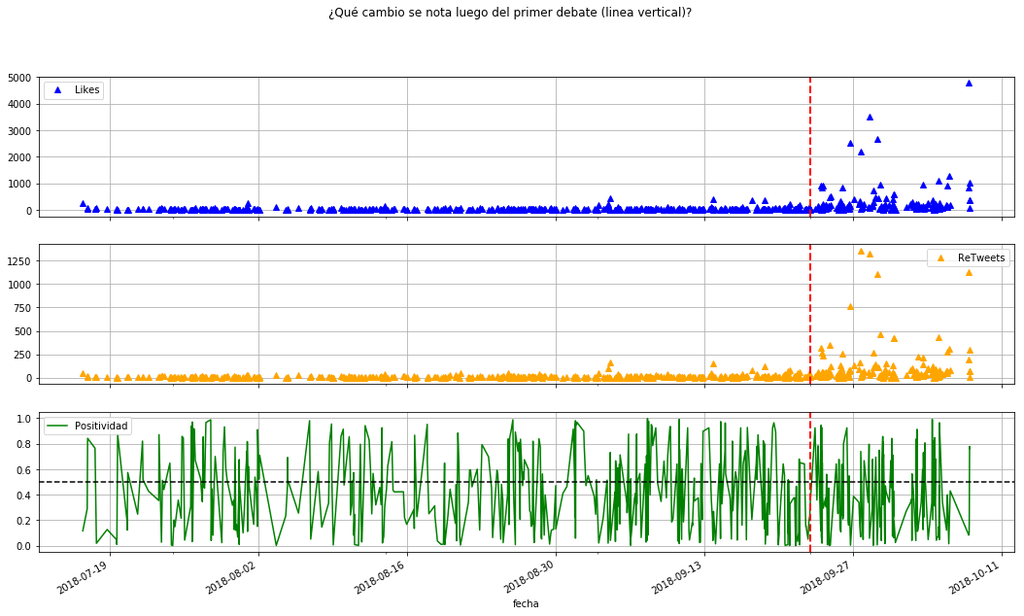

```
Cantidad de Tweets:  690
```

INICIO

## Los mensajes de Jaime Salinas

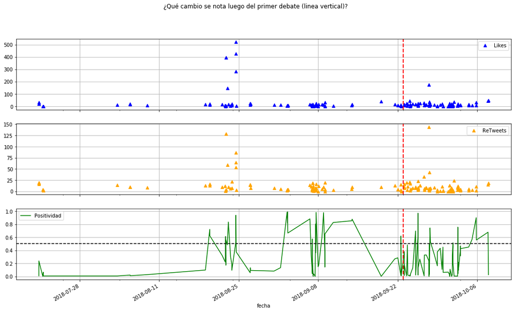

```
Cantidad de Tweets:  156
```

INICIO

## Los mensajes de Julio Gago

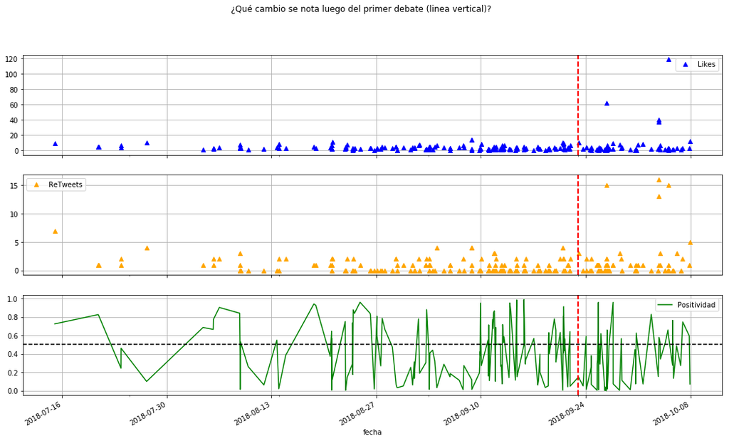

```
Cantidad de Tweets:  219
```

INICIO

## Los mensajes de Enrique Cornejo

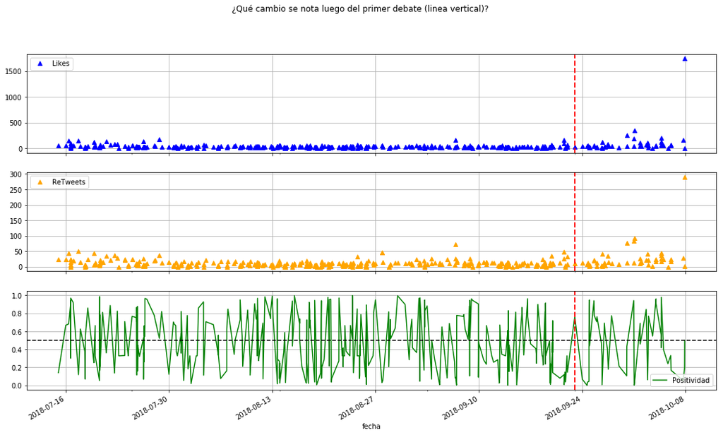

```
Cantidad de Tweets:  404
```

INICIO

## Los mensajes de Enrique Fernandez

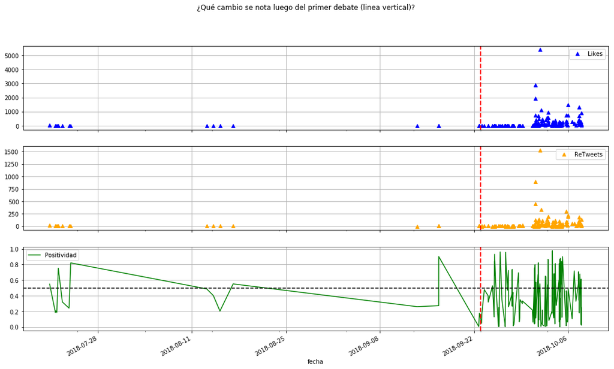

```
Cantidad de Tweets:  188
```

INICIO

## Los mensajes de Dietel Columbus

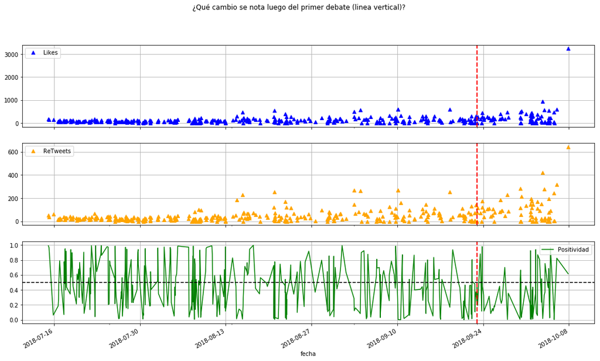

```
Cantidad de Tweets:  415
```

INICIO

## Los mensajes de Gustavo Guerra García

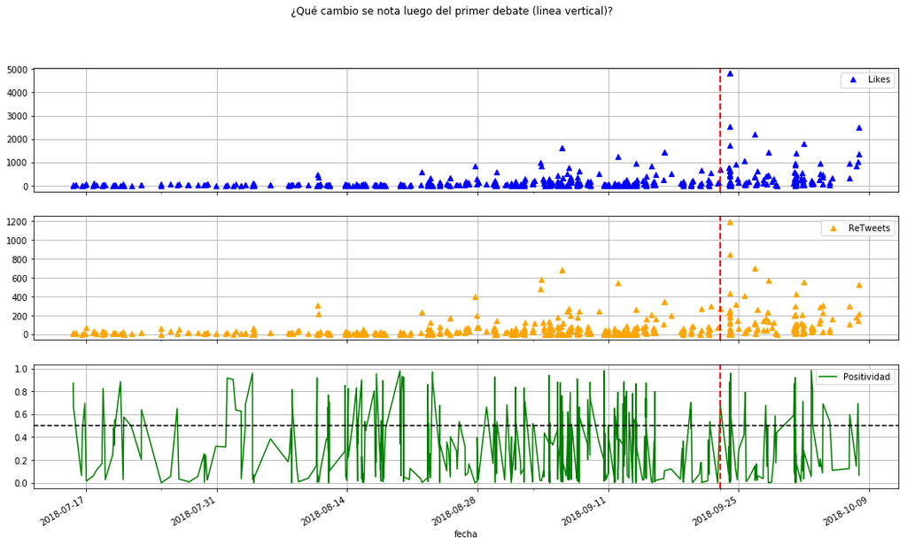

```
Cantidad de Tweets:  711
```

INICIO

## Los mensajes de Juan Carlos Zurek

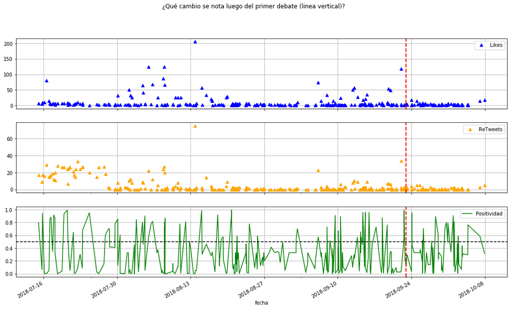

```
Cantidad de Tweets:  369
```

INICIO

## Los mensajes de Enrique Ocrospoma

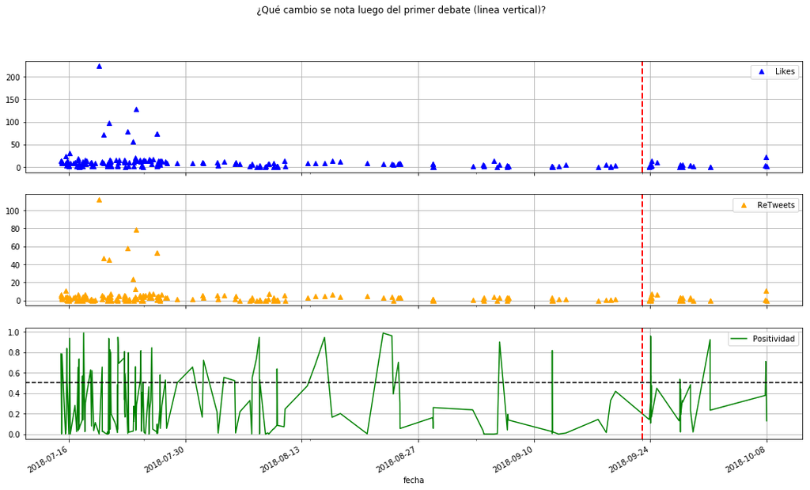

```
Cantidad de Tweets:  222
```

INICIO

## Los mensajes de Jorge Villacorta

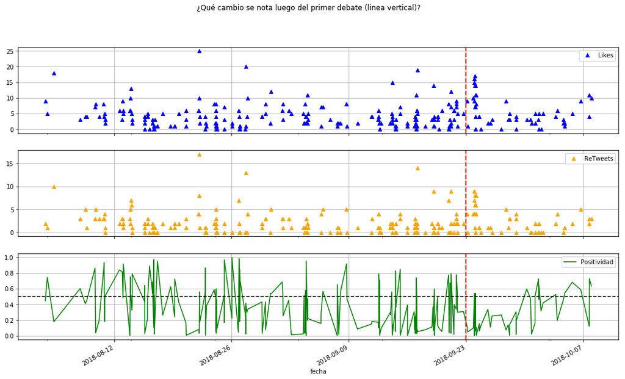

```
Cantidad de Tweets:  278
```

INICIO

## Los mensajes de Manuel Velarde

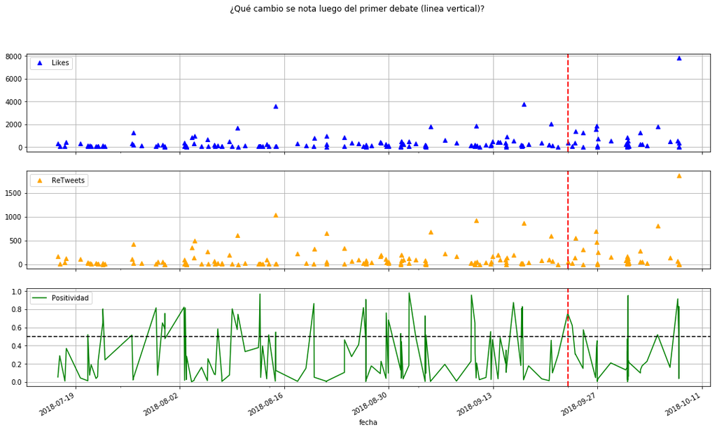

```
Cantidad de Tweets:  194
```

INICIO

## Los mensajes de Gómez Baca

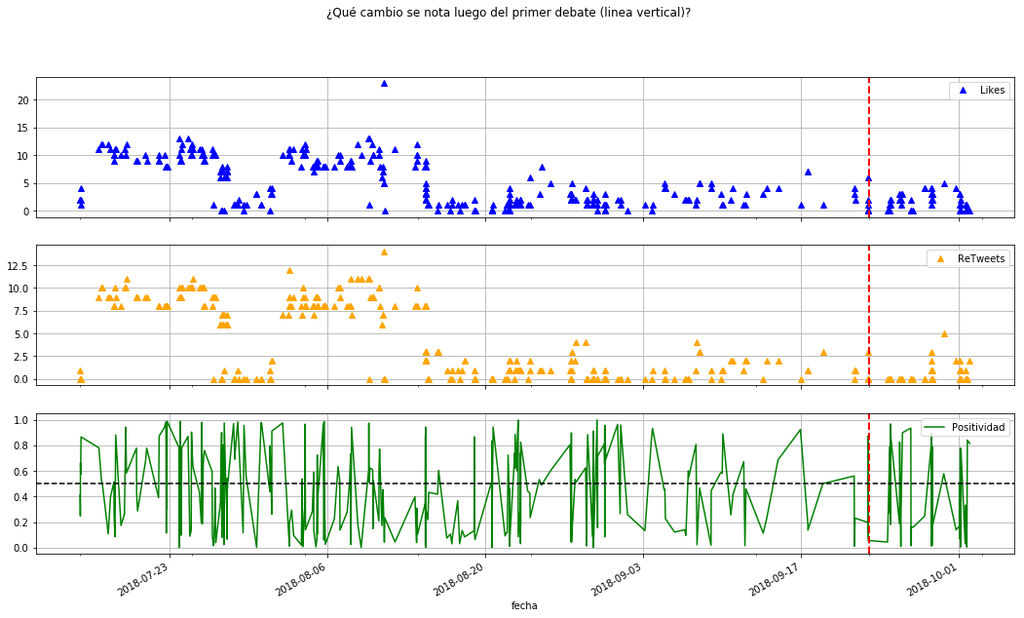

```
Cantidad de Tweets:  428
```

[MENU](https://ermperu.github.io/elecciones2018/)